# Visualisation les distribution

# 1 Introduction

Un histogramme ou une courbe de densité permet de voir la distribution des données.

# 2 Distribution en fonction des heures

## 2.1 Au cours d’une journée

Précédemment, on a visualiser l’évolution au cours du temps grâce à un graphique à lignes. La hauteur de la ligne représente la moyenne des accidents à une heure donnée.

Ce qui serait intéressant aussi, c’est de voir la distribution des points à une heure donnée. Pour cela, on va créer un graphique à boîtes à moustaches.

- On peut créer une série de données qui compte le nombre d’accidents par date, et heure.
- On peut enlever des points aberrants (en fonction de l’heure)
- On peut maintenant créer un graphique à boîtes à moustache.

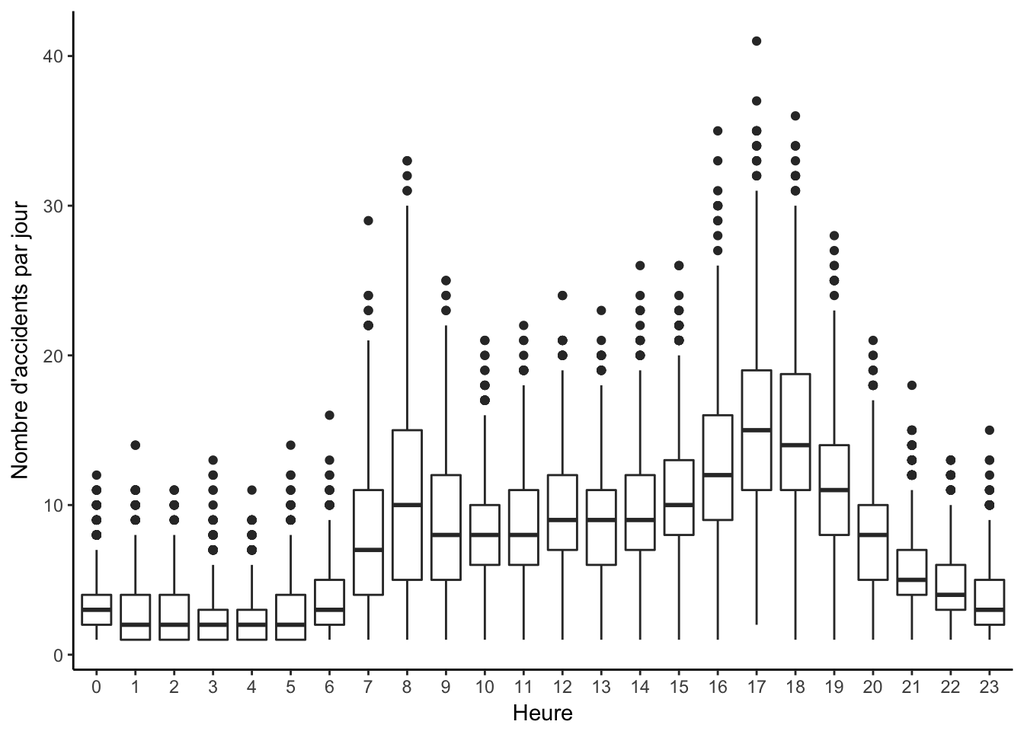

```r
caracteristiques_djh=caracteristiques[,.(nb=.N),by=c("date","heure","jsem")]

caracteristiques_djh=caracteristiques_djh[caracteristiques_djh$heure<=24,]

ggplot(caracteristiques_djh,aes(as.factor(heure),nb))+geom_boxplot()+xlab("heure")+
  theme_classic()+labs(x="Heure",y="Nombre d'accidents par jour")
```

## 2.2 Comparaison des jours de la semaine

Comme précédemment, on peut voir les distributions en fonction des jours de la semaine:

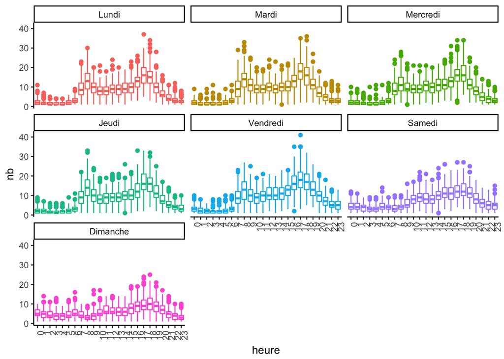

```r
ggplot(caracteristiques_djh,aes(as.factor(heure),nb,colour=jsem))+geom_boxplot()+xlab("heure")+
  theme_classic()+
  facet_wrap(~jsem)+ theme(axis.text.x = element_text(angle = 90, hjust = 1))+ guides(colour=FALSE)
```

# 3 Distribution au cours de la journée

On peut voir la distribution du nombre d’accidents au cours d’une journée. Dans la partie évolution, on a déjà compté le nombre d’accidents en fonction des heures, cela revient à faire un histogramme. On peut créer une densité de distribution, et on peut aussi faire des comparaisons de ces densités.

## 3.1 Jours de la semaine

Pour créer les distributions en fonction des jours de la semaine, on doit

- nettoyer comme précédent les données en fonction de la variable heure
- créer un graphique avec `geom_density` avec la couleur qui représente les jours de la semaine.

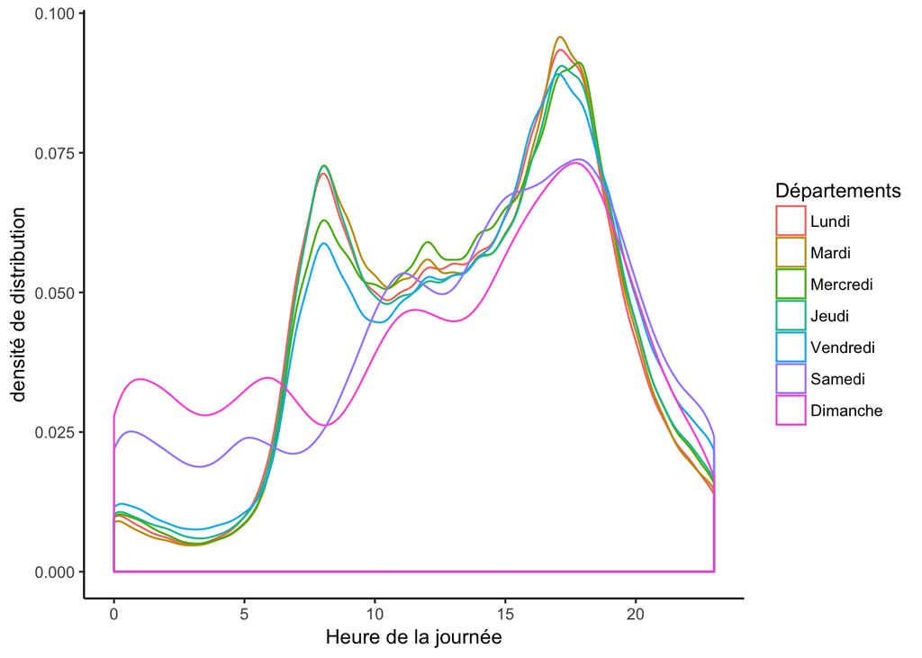

```r
caracteristiques2=caracteristiques[caracteristiques$heure<=24,]

ggplot(caracteristiques2,aes((heure),color=jsem))+geom_density()+xlab("heure")+
  theme_classic()+labs(x="Heure de la journée",y="densité de distribution",
                       color="Départements")
```

## 3.2 Comparaisons entre départements

On peut aussi comparer la distribution entre plusieurs départements

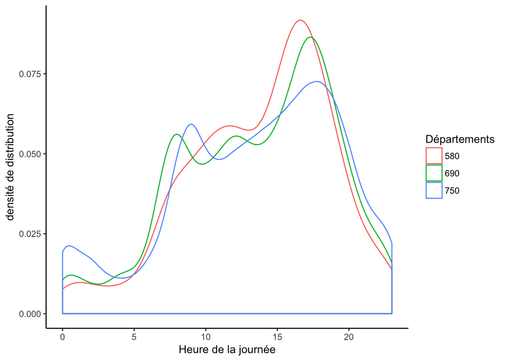

```r
caracteristiques2=caracteristiques[dep %in% c(750,690,580) & caracteristiques$heure<=24,]

ggplot(caracteristiques2,aes((heure),color=as.factor(dep)))+geom_density()+xlab("heure")+
  theme_classic()+labs(x="Heure de la journée",y="densité de distribution",
                       color="Départements")
```

Puis, on peut aussi comparer les départements en fonction des jours de la semaine, à l’aide de `facet` sur les jours de la semaine.

Ainsi on voit la différents entre les départements pour chaque jour de la semaine.

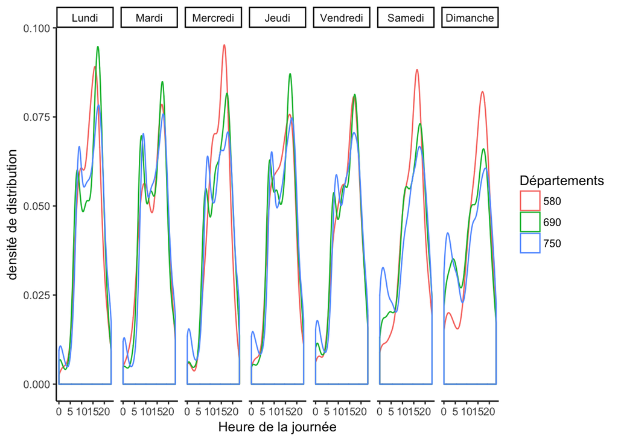

```r
ggplot(caracteristiques2,aes((heure),color=as.factor(dep)))+geom_density()+xlab("heure")+
  theme_classic()+labs(x="Heure de la journée",y="densité de distribution",
                       color="Départements")+facet_grid(~jsem)
```

On peut aussi représenter les départements à l’aide de `facet`. De cette façon, on voit mieux la différence dans la distribtion pour les différents jours de la semaine, pour un département donné.

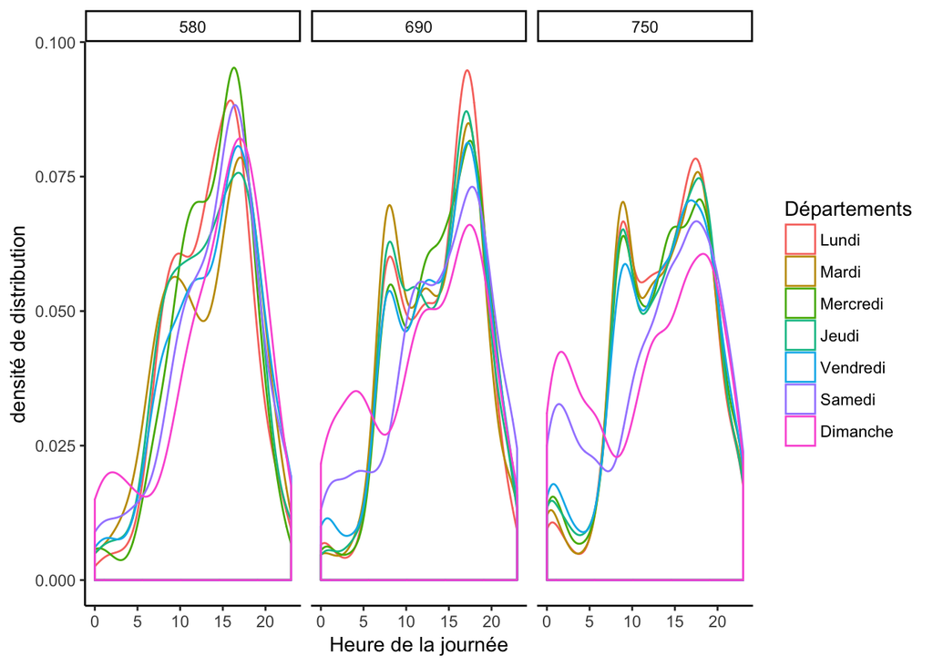

```r
ggplot(caracteristiques2,aes((heure),color=as.factor(jsem)))+geom_density()+xlab("heure")+
  theme_classic()+labs(x="Heure de la journée",y="densité de distribution",
                       color="Départements")+facet_grid(~as.factor(dep))
```

# 4 Densité des âges

On peut représenter la distribution du nombre d’accident en fonction de l’âge.

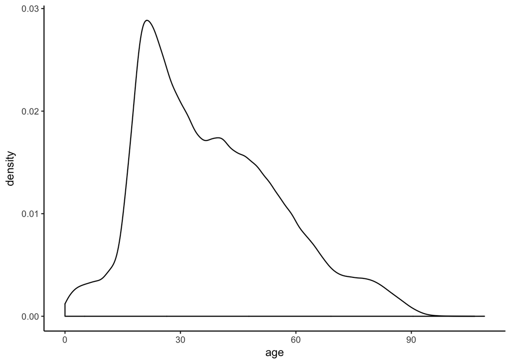

```r
ggplot(usagers,aes(age))+geom_density()+theme_classic()
```

Afin de mieux comparer la différence des niveaux de gravité, on peut les afficher en différentes couleurs.

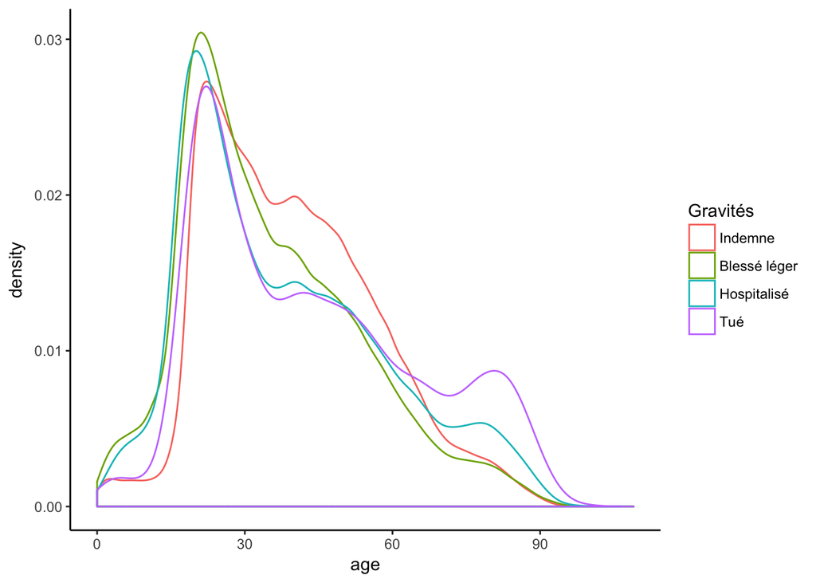

```r
ggplot(usagers,aes(age,colour=gravc))+geom_density()+theme_classic()+ guides(colour=guide_legend(title="Gravités"))
```

Si on souhaite avoir la différence entre les catégories d’usagers:

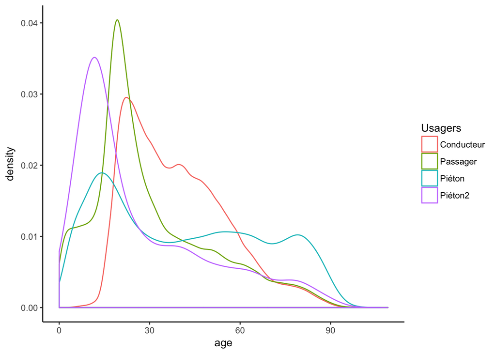

```r
ggplot(usagers,aes(age,colour=catuc))+geom_density()+theme_classic()+ guides(colour=guide_legend(title="Usagers"))
```

On créer utiliser `facet` pour distinguer les différentes distributions.

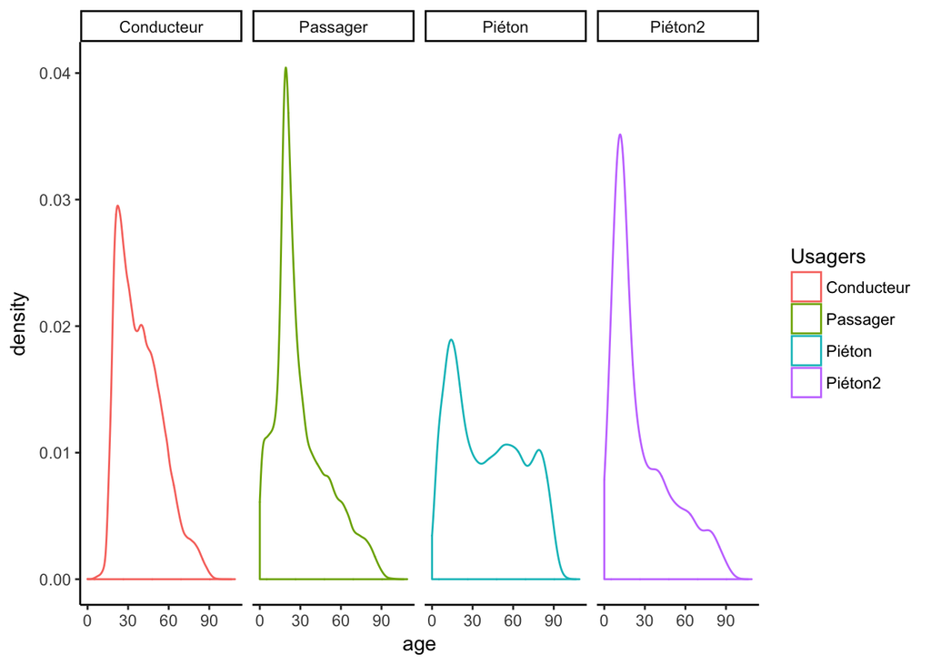

```r
ggplot(usagers,aes(age,colour=catuc))+geom_density()+theme_classic()+ guides(colour=guide_legend(title="Usagers"))+
  facet_grid(~catuc)
```

# 5 Distribution 2d

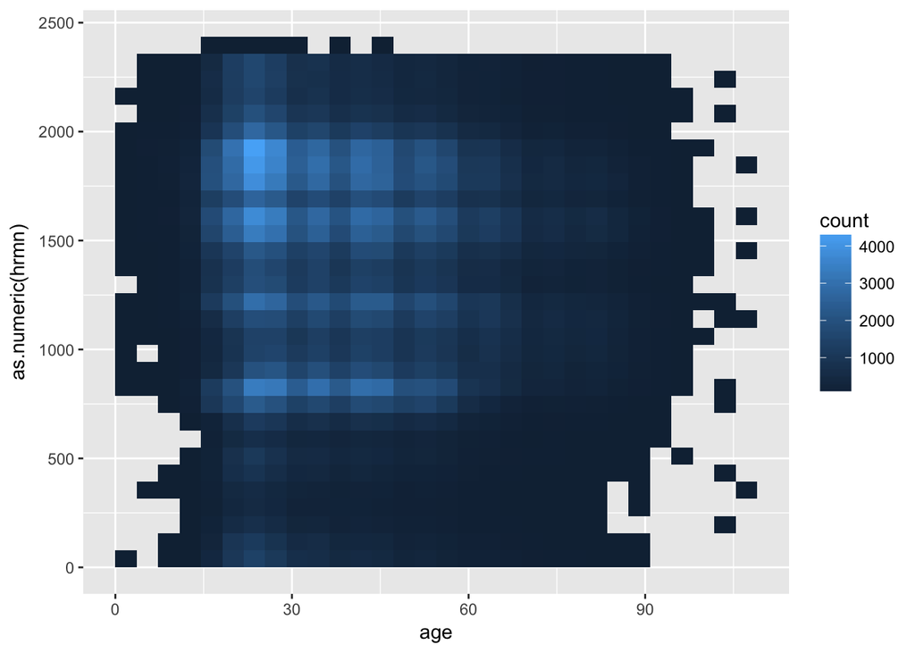

```r
conducteurs=usagers[usagers$catu=="1",]
cu=merge(caracteristiques,conducteurs,by="Num_Acc")

ggplot(cu,aes(x=age,y=as.numeric(hrmn)))+geom_bin2d()
```